[figure not shown]

# Discrete STFT: Frequency Resolution

## DFT with Increased Frequency Resolution

Let $x\in \mathbb{R}^N$ be discrete signal of length $N\in\mathbb{N}$ with samples $x(0), x(1), \ldots, x(N-1)$. Given the sampling $F_\mathrm{s}$, we assume that $x$ is obtained by sampling a continues-time signal $f:\mathbb{R}\to\mathbb{R}$. Then, the **discrete Fourier transform** (DFT) $X := \mathrm{DFT}_N \cdot x$ can be interpreted as an approximation of $\hat{f}$ for certain frequencies (see Equation (2.132) of [[Müller, FMP, Springer 2015]](http://www.music-processing.de/)):

$$ X(k) := \sum_{n=0}^{N-1} x(n) \exp(-2 \pi i k n / N) \approx {F_\mathrm{s}} \cdot \hat{f} \left(k \cdot \frac{F_\mathrm{s}}{N}\right) $$

for $k\in[0:N-1]$. Thus, the index $k$ of $X(k)$ corresponds to the physical frequency

\begin{equation} F_\mathrm{coef}^N(k) := \frac{k\cdot F_\mathrm{s}}{N} \end{equation}

given in Hertz. Intuitively speaking, the discrete Fourier transform introduces a linear frequency resolution of $F_\mathrm{s}/N$ that depends on the size $N$ of the $\mathrm{DFT}_N$. To increase the frequency resolution, one idea is to increase the size of the DFT. Let $L\in\mathbb{N}$ with $L\geq N$. Then, we apply zero padding to the right of the signal $x$ obtaining the signal $\tilde{x}\in \mathbb{R}^L$:

\begin{equation} \tilde{x}(n) :=\left\{\begin{array}{ll} x(n) ,& \,\,\mbox{for}\,\, n \in[0:N-1],\\ 0, & \,\,\mbox{for}\,\, n \in[N:L-1]. \end{array}\right. \end{equation}

Applying a $\mathrm{DFT}_L$, we obtain:

$$ \tilde{X}(k) = \mathrm{DFT}_L \cdot \tilde{x} = \sum_{n=0}^{L-1} \tilde{x}(n) \exp(-2 \pi i k n / L) = \sum_{n=0}^{N-1} x(n) \exp(-2 \pi i k n / L) \approx {F_\mathrm{s}} \cdot \hat{f} \left(k \cdot \frac{F_\mathrm{s}}{L}\right) $$

for $k\in[0:L-1]$. The coefficient $\tilde{X}(k)$ now corresponds to the physical frequency

\begin{equation} F_\mathrm{coef}^L(k) := \frac{k\cdot F_\mathrm{s}}{L}, \end{equation}

thus introducing a linear frequency resolution of $F_\mathrm{s}/L$. For example, if $L=2N$, the frequency resolution is increased by a factor of $2$. In other words, the longer DFT results in more frequency bins that are more closely spaced. However, note that this trick does **not** improve the approximation quality of the DFT (the number of summands in the Riemann approximation is still $N$). Only, the linear sampling of the frequency axis is refined when using $L\geq N$ and zero padding. The following example compares $\mathrm{DFT}_N \cdot x$ with $\mathrm{DFT}_L \cdot \tilde{x}$.

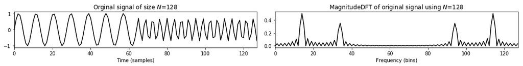

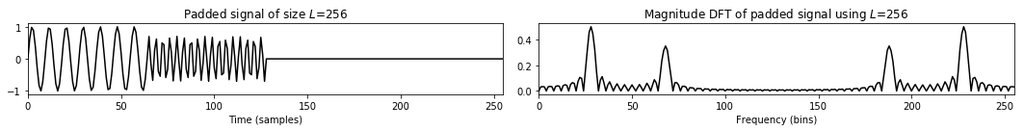

```python
import numpy as np
import scipy
from  matplotlib import pyplot as plt
import matplotlib
%matplotlib inline
import librosa

Fs = 64
duration = 2
omega1 = 7
omega2 = 17
N = duration * Fs
t = np.arange(0, N) * 1 / Fs
t1 = t[:N//2]
t2 = t[N//2:]

x1 = 1.0 * np.sin(2 * np.pi * omega1 * t1)
x2 = 0.7 * np.sin(2 * np.pi * omega2 * t2)
x = np.concatenate((x1, x2))

plt.figure(figsize=(15, 2))
ax1 = plt.subplot(1, 2, 1)
plt.plot(x, c='k')
plt.title('Orginal signal of size $N$=%d' %N)
plt.xlabel('Time (samples)')
plt.xlim([0, N-1])
plt.subplot(1, 2, 2)
Y = np.abs(np.fft.fft(x)) / Fs
plt.plot(Y, c='k')
plt.title('MagnitudeDFT of original signal using $N$=%d' %N)
plt.xlabel('Frequency (bins)')
plt.xlim([0, N-1])
plt.tight_layout()

L = 2*N
pad_len = L-N
t_tilde = np.concatenate((t, np.arange(len(x), len(x) + pad_len) / Fs))
x_tilde = np.concatenate((x, np.zeros(pad_len)))

plt.figure(figsize=(15, 2))
ax1 = plt.subplot(1, 2, 1)
plt.plot(x_tilde, c='k')
plt.title('Padded signal of size $L$=%d' %L)
plt.xlabel('Time (samples)')
plt.xlim([0, L-1])
plt.subplot(1, 2, 2)
Y_tilde = np.abs(np.fft.fft(x_tilde)) / Fs
plt.plot(Y_tilde, c='k')
plt.title('Magnitude DFT of padded signal using $L$=%d' %L)
plt.xlabel('Frequency (bins)')
plt.xlim([0, L-1])
plt.tight_layout()
```

The next code example implements a function for computing the DFT with increased frequency resolution, where all parameters are interpreted in a physical way (in terms of seconds and Hertz).

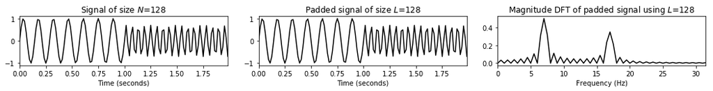

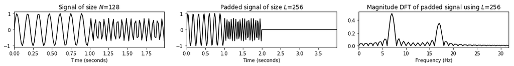

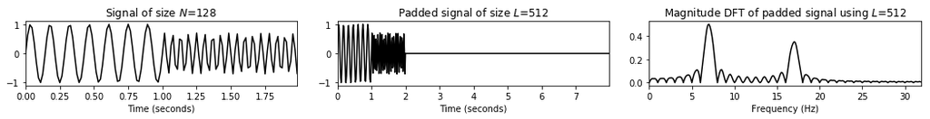

```python
def compute_plot_DFT_extended(t, x, Fs, L):
    N = len(x)
    pad_len = L-N
    t_tilde = np.concatenate((t, np.arange(len(x), len(x) + pad_len) / Fs))
    x_tilde = np.concatenate((x, np.zeros(pad_len)))
    Y = np.abs(np.fft.fft(x_tilde)) / Fs
    Y = Y[:L//2]
    freq = np.arange(L//2)*Fs/L
    # freq = np.fft.fftfreq(L, d=1/Fs)
    # freq = freq[:L//2]
    plt.figure(figsize=(15, 2))

    ax1 = plt.subplot(1, 3, 1)
    plt.plot(t_tilde, x_tilde, c='k')
    plt.title('Signal of size $N$=%d' %N)
    plt.xlabel('Time (seconds)')
    plt.xlim([t[0], t[-1]])

    ax1 = plt.subplot(1, 3, 2)
    plt.plot(t_tilde, x_tilde, c='k')
    plt.title('Padded signal of size $L$=%d' %L)
    plt.xlabel('Time (seconds)')
    plt.xlim([t_tilde[0], t_tilde[-1]])

    ax2 = plt.subplot(1, 3, 3)
    plt.plot(freq, Y, c='k')
    plt.title('Magnitude DFT of padded signal using $L$=%d' %L)
    plt.xlabel('Frequency (Hz)')
    plt.xlim([freq[0], freq[-1]])
    plt.tight_layout()

    ax1 = 1
    ax2 = 2
    return ax1, ax2


N = len(x)
L = N
ax1, ax2 = compute_plot_DFT_extended(t, x, Fs, L)

L = 2*N
ax1, ax2 = compute_plot_DFT_extended(t, x, Fs, L)

L = 4*N
ax1, ax2 = compute_plot_DFT_extended(t, x, Fs, L)
```

## STFT with Increased Frequency Resolution

We now show how the same zero-padding strategy can be used to increase the frequency resolution of an STFT. The `librosa` function `librosa.stft` implements this idea by means of the two parameters `n_fft` (correponding to $L$) and `win_length` (correponding to $N$). Care has to be taken when converting the parameters to the physical domain. Our example is the note C4 played by a violin (with vibrato).

```
t[0]= 0.0 , t[-1]= 4.23174603175
```

[interactive chart not shown]

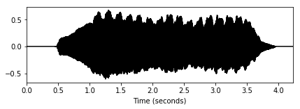

```python
import os
import IPython.display as ipd

# Load wav
fn_wav = os.path.join('..', 'data', 'C2', 'FMP_C2_F05c_C4_violin.wav')

Fs = 11025
x, Fs = librosa.load(fn_wav, sr=Fs)
ipd.Audio(x, rate=Fs)
t_wav = np.arange(0, x.shape[0]) * 1/Fs

print('t[0]=', t_wav[0],', t[-1]=', t_wav[-1])
ipd.display(ipd.Audio(x, rate=Fs))

plt.figure(figsize=(15, 2))
ax1 = plt.subplot(1, 2, 1)
plt.plot(t_wav, x, c='k')
plt.xlim([t_wav[0], t_wav[-1]])
plt.xlabel('Time (seconds)');
```

We now compute an STFT with zero-padding. In the visualization, the axis are shown in terms of time frames and frequency bins.

```
Y.shape = [ 129,  730], Fs = 11025, N =  256, L =  256, freq = [ 0.0, 5512.5], freq_res = 43.1, t = [0.000, 4.232]
Y.shape = [ 257,  730], Fs = 11025, N =  256, L =  512, freq = [ 0.0, 5512.5], freq_res = 21.5, t = [0.000, 4.232]
Y.shape = [ 513,  730], Fs = 11025, N =  256, L = 1024, freq = [ 0.0, 5512.5], freq_res = 10.8, t = [0.000, 4.232]
```

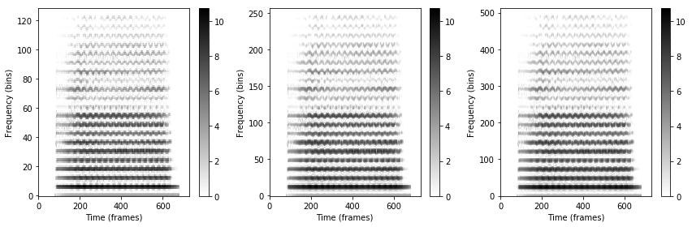

```python
def compute_stft(x, Fs, N, H, L=N, pad_mode='constant', center=True, print_para=False):
    X = librosa.stft(x, n_fft=L, hop_length=H, win_length=N,
                 window='hann', pad_mode=pad_mode, center=center)
    Y = np.log(1 + 100 * np.abs(X) ** 2)
    F_coef = librosa.fft_frequencies(sr=Fs, n_fft=L)
    T_coef = librosa.frames_to_time(np.arange(X.shape[1]), sr=Fs, hop_length=H)
    if print_para:
        print('Y.shape = [%4d, %4d], Fs = %d, N = %4d, L = %4d, freq = [%4.1f, %4.1f], freq_res = %4.1f, t = [%4.3f, %4.3f]'
              %(Y.shape[0],Y.shape[1], Fs, N, L, F_coef[0], F_coef[-1], F_coef[1]-F_coef[0], T_coef[0], T_coef[-1]))
    return Y, F_coef, T_coef

N = 256
H = 64
color = 'gray_r'
plt.figure(figsize=(12, 4))

plt.subplot(1,3,1)
L = N
Y, F_coef, T_coef = compute_stft(x, Fs, N, H, L, print_para=True)
plt.imshow(Y, cmap=color , aspect='auto', origin='lower');
plt.xlabel('Time (frames)')
plt.ylabel('Frequency (bins)')
plt.colorbar()

plt.subplot(1,3,2)
L = 2*N
Y, F_coef, T_coef = compute_stft(x, Fs, N, H, L, print_para=True)
plt.imshow(Y, cmap=color , aspect='auto', origin='lower');
plt.xlabel('Time (frames)')
plt.ylabel('Frequency (bins)')
plt.colorbar()

plt.subplot(1,3,3)
L = 4*N
Y, F_coef, T_coef = compute_stft(x, Fs, N, H, L, print_para=True)
plt.imshow(Y, cmap=color , aspect='auto', origin='lower');
plt.xlabel('Time (frames)')
plt.ylabel('Frequency (bins)')
plt.colorbar()
plt.tight_layout()
```

Next, we repeat the same computation, where the axis are now converted to show physical units specified in seconds and Hertz. Furthermore, we zoom into the time-frequency plane to highly the "smoothing" effect when using an larger DFT.

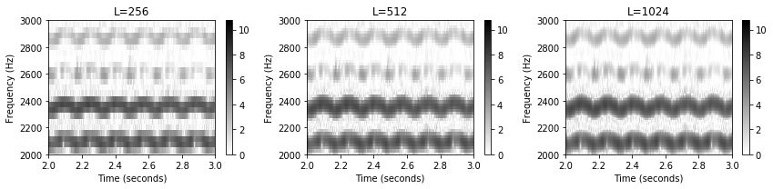

```python
plt_interval_seconds = [2, 3]
plt_interval_freq_hz = [2000, 3000]
plt.figure(figsize=(12, 3))

L = N
Y, F_coef, T_coef = compute_stft(x, Fs, N, H, L)
extent=[T_coef[0], T_coef[-1], F_coef[0], F_coef[-1]]
plt.subplot(1,3,1)
plt.imshow(Y, cmap=color , aspect='auto', origin='lower', extent=extent);
plt.xlabel('Time (seconds)')
plt.ylabel('Frequency (Hz)')
plt.title('L=%d' %L)
plt.ylim(plt_interval_freq_hz)
plt.xlim(plt_interval_seconds)
plt.colorbar()

L = 2*N
Y, F_coef, T_coef = compute_stft(x, Fs, N, H, L)
plt.subplot(1,3,2)
extent=[T_coef[0], T_coef[-1], F_coef[0], F_coef[-1]]
plt.imshow(Y, cmap=color , aspect='auto', origin='lower', extent=extent);
plt.xlabel('Time (seconds)')
plt.ylabel('Frequency (Hz)')
plt.title('L=%d' %L)
plt.ylim(plt_interval_freq_hz)
plt.xlim(plt_interval_seconds)
plt.colorbar()

L = 4*N
Y, F_coef, T_coef = compute_stft(x, Fs, N, H, L)
plt.subplot(1,3,3)
extent=[T_coef[0], T_coef[-1], F_coef[0], F_coef[-1]]
plt.imshow(Y, cmap=color , aspect='auto', origin='lower', extent=extent);
plt.xlabel('Time (seconds)')
plt.ylabel('Frequency (Hz)')
plt.title('L=%d' %L)
plt.ylim(plt_interval_freq_hz)
plt.xlim(plt_interval_seconds)
plt.colorbar()
plt.tight_layout()
```

## Reshaping the Frequency Axis Using Interpolation Techniques

As an alternative of using a larger DFT based on zero-padding to increase the STFT frequency resolution, one may simply use interpolation techniques along the frequency direction to adjust the frequency resolution. The following code example shows how to use the function `scipy.inperploate.interp1d` to implement this idea.

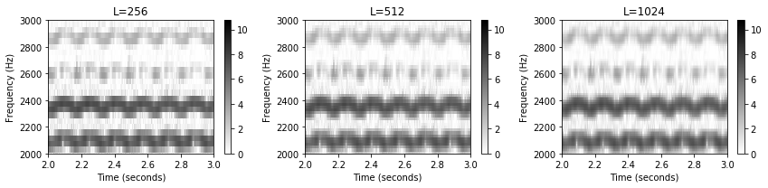

```python
from scipy.interpolate import interp1d

plt.figure(figsize=(12, 3))

X = librosa.stft(x, n_fft=N, hop_length=H, win_length=N, window='hann', pad_mode='constant', center=True)
Y = np.log(1 + 100 * np.abs(X) ** 2)
T_coef = np.arange(0, X.shape[1]) * H/Fs
F_coef = np.arange(0, N//2+1) * Fs/N

L = N
plt.subplot(1,3,1)
extent=[T_coef[0], T_coef[-1], F_coef[0], F_coef[-1]]
plt.imshow(Y, cmap=color , aspect='auto', origin='lower', extent=extent);
plt.xlabel('Time (seconds)')
plt.ylabel('Frequency (Hz)')
plt.title('L=%d' %L)
plt.ylim(plt_interval_freq_hz)
plt.xlim(plt_interval_seconds)
plt.colorbar()

L = 2*N
F_coef_new = np.arange(0, L//2+1) * Fs/L
compute_Y_interp = interp1d(F_coef, Y, kind='linear', axis=0)
Y_interp = compute_Y_interp(F_coef_new)
plt.subplot(1,3,2)
extent=[T_coef[0], T_coef[-1], F_coef_new[0], F_coef_new[-1]]
plt.imshow(Y_interp, cmap=color , aspect='auto', origin='lower', extent=extent);
plt.xlabel('Time (seconds)')
plt.ylabel('Frequency (Hz)')
plt.title('L=%d' %L)
plt.ylim(plt_interval_freq_hz)
plt.xlim(plt_interval_seconds)
plt.colorbar()

L = 4*N
F_coef_new = np.arange(0, L//2+1) * Fs/L
compute_Y_interp = interp1d(F_coef, Y, kind='linear', axis=0)
Y_interp = compute_Y_interp(F_coef_new)
plt.subplot(1,3,3)
extent=[T_coef[0], T_coef[-1], F_coef_new[0], F_coef_new[-1]]
plt.imshow(Y_interp, cmap=color , aspect='auto', origin='lower', extent=extent);
plt.xlabel('Time (seconds)')
plt.ylabel('Frequency (Hz)')
plt.title('L=%d' %L)
plt.ylim(plt_interval_freq_hz)
plt.xlim(plt_interval_seconds)
plt.colorbar()
plt.tight_layout()
```

This interpolation techniques can be also used for a non-linear deformation of the frequency axis. In the following code example, the linearly spaced frequency axis is transformed into a logarithmically spaced axis.

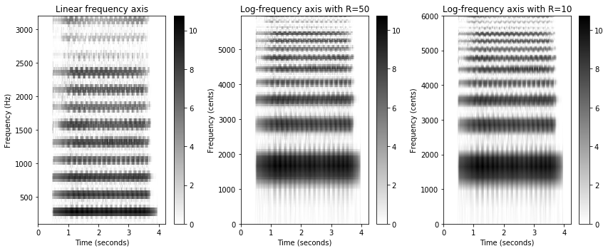

```python
def log_spec_via_interp(Y, F_coef, R, F_min, F_max):
    # R = resolution (cents)
    # F_min = minimum frequency
    # F_max = maximum frequency
    n_bins = np.ceil(1200 * np.log2(F_max / F_min) / R).astype(int)
    F_coef_log = 2 ** (np.arange(0, n_bins) * R / 1200) * F_min
    compute_Y_interp = interp1d(F_coef, Y, kind='linear', axis=0)
    Y_interp = compute_Y_interp(F_coef_log)
    F_coef_cents = np.arange(0, n_bins) * 1200 * np.log2(F_max / F_min)/n_bins
    return Y_interp, F_coef_log, F_coef_cents

F_min = 100
F_max = 3200

plt.figure(figsize=(12, 5))
plt.subplot(1,3,1)
extent=[T_coef[0], T_coef[-1], F_coef[0], F_coef[-1]]
plt.imshow(Y, cmap=color , aspect='auto', origin='lower', extent=extent);
plt.xlabel('Time (seconds)')
plt.ylabel('Frequency (Hz)')
plt.title('Linear frequency axis')
plt.ylim([F_min, F_max])
plt.colorbar()

R = 50
Y_interp, F_coef_log, F_coef_cents = log_spec_via_interp(Y, F_coef, R, F_min, F_max)

plt.subplot(1,3,2)
extent=[T_coef[0], T_coef[-1], F_coef_cents[0], F_coef_cents[-1]]
plt.imshow(Y_interp, cmap=color , aspect='auto', origin='lower', extent=extent);
plt.xlabel('Time (seconds)')
plt.ylabel('Frequency (cents)')
plt.title('Log-frequency axis')
plt.title('Log-frequency axis with R=%d'%R)
plt.colorbar()

R = 10
Y_interp, F_coef_log, F_coef_cents = log_spec_via_interp(Y, F_coef, R, F_min, F_max)

plt.subplot(1,3,3)
extent=[T_coef[0], T_coef[-1], F_coef_cents[0], F_coef_cents[-1]]
plt.imshow(Y_interp, cmap=color , aspect='auto', origin='lower', extent=extent);
plt.xlabel('Time (seconds)')
plt.ylabel('Frequency (cents)')
plt.title('Log-frequency axis with R=%d'%R)
plt.colorbar()
plt.tight_layout()
```

**Acknowledgment:** This notebook was created by [Meinard Müller](https://www.audiolabs-erlangen.de/fau/professor/mueller), [Frank Zalkow](https://www.audiolabs-erlangen.de/fau/assistant/zalkow), and [Sebastian Rosenzweig](https://www.audiolabs-erlangen.de/fau/assistant/rosenzweig).